# Credit Risk Score Prediction using Machine Learning

## 2. Introduction

Credit risk prediction is the process of estimating the likelihood that a borrower will fail to repay a loan. Lenders use this assessment to decide whether to approve a loan, at what interest rate, and for what amount. Banks and financial institutions face significant financial exposure when lending money. Without robust risk assessment, banks may approve loans for applicants who are likely to default, resulting in direct financial losses, increased non-performing assets, and regulatory penalties. Accurate risk scoring ensures that lending decisions are data-driven rather than subjective. Machine learning automates the credit risk evaluation process by learning patterns from historical lending data. Models can simultaneously weigh dozens of financial and demographic features — far beyond what a manual review could efficiently handle — producing consistent, scalable, and objective risk scores in real time.

### ML Pipeline Overview

This project follows a structured end-to-end pipeline:

1. **Data Collection** – Load and inspect the dataset
2. **Data Preparation** – Clean missing values, encode categorical variables
3. **Exploratory Data Analysis (EDA)** – Visualise distributions, outliers, and correlations
4. **Feature Engineering** – Create domain-informed derived features
5. **Model Training** – Train Linear Regression, Decision Tree, and Random Forest regressors
6. **Hyperparameter Tuning** – Use GridSearchCV and cross-validation
7. **Model Evaluation** – Compare models using RMSE, MAE, and R²
8. **Business Insights** – Translate model findings into actionable recommendations

## 3. Business Problem

Banks and lending institutions face a critical challenge in evaluating loan applicants accurately and efficiently. Every year, financial institutions process millions of loan applications, and a single wrong decision — whether approving a high-risk borrower or rejecting a creditworthy one — can result in significant financial and reputational damage. Traditionally, loan officers manually reviewed each application by examining income statements, credit history, and employment records, a process that was slow, expensive, inconsistent, and prone to human bias. The absence of a fast, objective, and data-driven system forces banks to either take on excessive risk by approving borderline applicants or lose business by being overly conservative, both of which hurt profitability and competitiveness. To solve this, the target variable loan_int_rate is used as a credit risk score — where a higher predicted interest rate indicates a riskier borrower — enabling banks to make smarter, faster, and fairer lending decisions at scale.

## 4. Goal Definition

**Project Goal:** The goal of this project is to build a complete end-to-end machine learning pipeline that predicts the credit risk score of a loan applicant, represented by the loan interest rate (loan_int_rate), using customer financial and demographic information. By training and comparing multiple regression models — Linear Regression, Decision Tree Regressor, and Random Forest Regressor — the pipeline identifies the most accurate and reliable model for predicting credit risk. The final model is evaluated using RMSE, MAE, and R² score to ensure it generalises well to unseen data and can support real-world lending decisions in the banking and FinTech industry.

## 5. Objectives

1. Understand and explore the dataset structure
2. Clean and preprocess the data (handle missing values, encode categoricals)
3. Perform exploratory data analysis (EDA) to uncover patterns and relationships
4. Engineer new features to improve predictive performance
5. Train machine learning models: Linear Regression, Decision Tree Regressor, Random Forest Regressor
6. Tune hyperparameters using GridSearchCV with cross-validation
7. Evaluate all models on unseen test data using RMSE, MAE, and R²
8. Identify the most important factors affecting credit risk
9. Provide actionable business insights and recommendations

## Step 1: Data Collection

In this step, we load the dataset into a pandas DataFrame and conduct an initial inspection to understand its structure, contents, and quality. This forms the foundation for all subsequent preprocessing and modelling steps.

```python
import pandas as pd
import numpy as np
import matplotlib.pyplot as plt
import warnings
warnings.filterwarnings('ignore')

# Load dataset
df = pd.read_csv('credit_risk_dataset.csv')
print("DATASET LOADED SUCCESSFULLY")
print(f"Shape: {df.shape[0]} rows × {df.shape[1]} columns")
```

```
DATASET LOADED SUCCESSFULLY
Shape: 32581 rows × 12 columns
```

```python
# First few rows
print("\n First 5 Rows of the Dataset:")
df.head()
```

```
 First 5 Rows of the Dataset:
```

|  | person_age | person_income | person_home_ownership | person_emp_length | loan_intent | loan_grade | loan_amnt | loan_int_rate | loan_status | loan_percent_income | cb_person_default_on_file | cb_person_cred_hist_length |
| --- | --- | --- | --- | --- | --- | --- | --- | --- | --- | --- | --- | --- |
| 0 | 22 | 59000 | RENT | 123.0 | PERSONAL | D | 35000 | 16.02 | 1 | 0.59 | Y | 3 |
| 1 | 21 | 9600 | OWN | 5.0 | EDUCATION | B | 1000 | 11.14 | 0 | 0.10 | N | 2 |
| 2 | 25 | 9600 | MORTGAGE | 1.0 | MEDICAL | C | 5500 | 12.87 | 1 | 0.57 | N | 3 |
| 3 | 23 | 65500 | RENT | 4.0 | MEDICAL | C | 35000 | 15.23 | 1 | 0.53 | N | 2 |
| 4 | 24 | 54400 | RENT | 8.0 | MEDICAL | C | 35000 | 14.27 | 1 | 0.55 | Y | 4 |

```python
# Column names and data types
print(" Column Names & Data Types:")
print(df.dtypes)
```

```
 Column Names & Data Types:
person_age                      int64
person_income                   int64
person_home_ownership          object
person_emp_length             float64
loan_intent                    object
loan_grade                     object
loan_amnt                       int64
loan_int_rate                 float64
loan_status                     int64
loan_percent_income           float64
cb_person_default_on_file      object
cb_person_cred_hist_length      int64
dtype: object
```

```python
# Summary statistics
print("Summary Statistics:")
df.describe()
```

```
Summary Statistics:
```

|  | person_age | person_income | person_emp_length | loan_amnt | loan_int_rate | loan_status | loan_percent_income | cb_person_cred_hist_length |
| --- | --- | --- | --- | --- | --- | --- | --- | --- |
| count | 32581.000000 | 3.258100e+04 | 31686.000000 | 32581.000000 | 29465.000000 | 32581.000000 | 32581.000000 | 32581.000000 |
| mean | 27.734600 | 6.607485e+04 | 4.789686 | 9589.371106 | 11.011695 | 0.218164 | 0.170203 | 5.804211 |
| std | 6.348078 | 6.198312e+04 | 4.142630 | 6322.086646 | 3.240459 | 0.413006 | 0.106782 | 4.055001 |
| min | 20.000000 | 4.000000e+03 | 0.000000 | 500.000000 | 5.420000 | 0.000000 | 0.000000 | 2.000000 |
| 25% | 23.000000 | 3.850000e+04 | 2.000000 | 5000.000000 | 7.900000 | 0.000000 | 0.090000 | 3.000000 |
| 50% | 26.000000 | 5.500000e+04 | 4.000000 | 8000.000000 | 10.990000 | 0.000000 | 0.150000 | 4.000000 |
| 75% | 30.000000 | 7.920000e+04 | 7.000000 | 12200.000000 | 13.470000 | 0.000000 | 0.230000 | 8.000000 |
| max | 144.000000 | 6.000000e+06 | 123.000000 | 35000.000000 | 23.220000 | 1.000000 | 0.830000 | 30.000000 |

```python
# Missing values
print("--- Missing Values ---")
missing = df.isnull().sum()
missing_pct = (missing / len(df) * 100).round(2)
missing_df = pd.DataFrame({'Missing Count': missing, 'Missing %': missing_pct})
print(missing_df[missing_df['Missing Count'] > 0])
```

```
--- Missing Values ---
                   Missing Count  Missing %
person_emp_length            895       2.75
loan_int_rate               3116       9.56
```

## Step 2: Data Preparation

Data preparation ensures the dataset is clean, consistent, and suitable for machine learning. We address missing values, encode categorical variables, and inspect for duplicates and outliers.

Missing values in a dataset can cause errors during model training and lead to biased or inaccurate predictions, so it is essential to handle them before proceeding. In this step, numeric columns are imputed using the **median** value — which is more robust to outliers than the mean — while categorical columns are imputed using the **mode** (most frequently occurring value). After imputation, a final check confirms that no missing values remain in the dataset, ensuring the data is clean and ready for the next stage of the pipeline.

```python
# Handle Missing Values
numeric_cols = df.select_dtypes(include=[np.number]).columns.tolist()
categorical_cols = df.select_dtypes(include=['object']).columns.tolist()
# Impute numeric columns with median (robust to outliers)
for col in numeric_cols:
    if df[col].isnull().sum() > 0:
        median_val = df[col].median()
        df[col].fillna(median_val, inplace=True)
        print(f"  [Numeric] '{col}' → filled with median ({median_val:.2f})")

# Impute categorical columns with mode
for col in categorical_cols:
    if df[col].isnull().sum() > 0:
        mode_val = df[col].mode()[0]
        df[col].fillna(mode_val, inplace=True)
        print(f"  [Categorical] '{col}' → filled with mode ('{mode_val}')")

print("\nMissing values after imputation:")
print(df.isnull().sum().sum(), "total missing values")
```

```
  [Numeric] 'person_emp_length' → filled with median (4.00)
  [Numeric] 'loan_int_rate' → filled with median (10.99)

Missing values after imputation:
0 total missing values
```

## Encode Categorical Variables

Machine learning models require all input features to be in numerical format, as they cannot directly process text or string values. In this step, **Label Encoding** is applied to convert categorical columns — `person_home_ownership`, `loan_intent`, `loan_grade`, and `cb_person_default_on_file` — into numerical representations. Each unique category is assigned a unique integer value, allowing the model to interpret and learn from these features effectively. After encoding, the dataset contains only numeric columns and is fully prepared for model training.

```python
# Encode Categorical Variables
from sklearn.preprocessing import LabelEncoder
le = LabelEncoder()
cat_encode_cols = ['person_home_ownership', 'loan_intent', 'loan_grade', 'cb_person_default_on_file']
for col in cat_encode_cols:
    if col in df.columns:
        df[col] = le.fit_transform(df[col])
        print(f"  Encoded '{col}'")

print("\nEncoded DataFrame dtypes:")
print(df.dtypes)
```

```
  Encoded 'person_home_ownership'
  Encoded 'loan_intent'
  Encoded 'loan_grade'
  Encoded 'cb_person_default_on_file'

Encoded DataFrame dtypes:
person_age                      int64
person_income                   int64
person_home_ownership           int64
person_emp_length             float64
loan_intent                     int64
loan_grade                      int64
loan_amnt                       int64
loan_int_rate                 float64
loan_status                     int64
loan_percent_income           float64
cb_person_default_on_file       int64
cb_person_cred_hist_length      int64
dtype: object
```

## Check for Duplicate Records

Duplicate records in a dataset can cause the model to overfit by learning the same pattern multiple times, leading to inflated performance metrics and poor generalisation on unseen data. In this step, the dataset is checked for any duplicate rows using pandas `duplicated()` function. If duplicates are found, they are automatically removed to ensure each record is unique and the model trains on clean, unbiased data.

## Check for Duplicate Records

Duplicate records in a dataset can cause the model to overfit by learning the same pattern multiple times, leading to inflated performance metrics and poor generalisation on unseen data. In this step, the dataset is checked for any duplicate rows using pandas `duplicated()` function. If duplicates are found, they are automatically removed to ensure each record is unique and the model trains on clean, unbiased data.

```python
# Duplicate Records
n_dupes = df.duplicated().sum()
print(f"Duplicate records found: {n_dupes}")
if n_dupes > 0:
    df.drop_duplicates(inplace=True)
    print(f"  → Duplicates removed. New shape: {df.shape}")
else:
    print("  → No duplicates found.")
```

```
Duplicate records found: 165
  → Duplicates removed. New shape: (32416, 12)
```

## Outlier Detection

Outliers are extreme values that differ significantly from the rest of the data and can negatively impact model performance, particularly for linear models. In this step, the **IQR (Interquartile Range) method** is used to detect outliers across key numeric columns — `person_income`, `loan_amnt`, `loan_int_rate`, `person_age`, and `person_emp_length`. Any value that falls below **Q1 − 1.5×IQR** or above **Q3 + 1.5×IQR** is flagged as an outlier. Rather than removing them immediately, outliers are retained for modelling but carefully examined in the EDA section to understand their distribution and potential impact on predictions.

```python
#  Outlier Detection
def detect_outliers_iqr(series):
    Q1, Q3 = series.quantile(0.25), series.quantile(0.75)
    IQR = Q3 - Q1
    lower, upper = Q1 - 1.5 * IQR, Q3 + 1.5 * IQR
    return ((series < lower) | (series > upper)).sum()

outlier_cols = ['person_income', 'loan_amnt', 'loan_int_rate', 'person_age', 'person_emp_length']
print("Outlier counts (IQR method):")
for col in outlier_cols:
    n_out = detect_outliers_iqr(df[col])
    print(f"  {col}: {n_out} outliers ({n_out/len(df)*100:.1f}%)")

print("\nOutliers are retained for modelling but highlighted in EDA.")
```

```
Outlier counts (IQR method):
  person_income: 1478 outliers (4.6%)
  loan_amnt: 1679 outliers (5.2%)
  loan_int_rate: 70 outliers (0.2%)
  person_age: 1491 outliers (4.6%)
  person_emp_length: 852 outliers (2.6%)

Outliers are retained for modelling but highlighted in EDA.
```

## Step 3: Exploratory Data Analysis (EDA)

EDA helps us understand the distribution of variables, identify patterns, detect anomalies, and discover relationships between features and the target variable. All visualisations are produced using **matplotlib only**.

## Histograms — Numeric Feature Distributions

Understanding the distribution of numeric features is a fundamental step in Exploratory Data Analysis (EDA). In this step, histograms are plotted for four key numeric columns — `person_age`, `person_income`, `loan_amnt`, and `loan_int_rate` (the target variable). Each histogram includes a **red dashed line representing the mean value**, making it easy to identify skewness, spread, and the central tendency of each feature. Analysing these distributions helps detect anomalies, understand the range of values, and guide preprocessing decisions such as scaling or outlier treatment before model training.

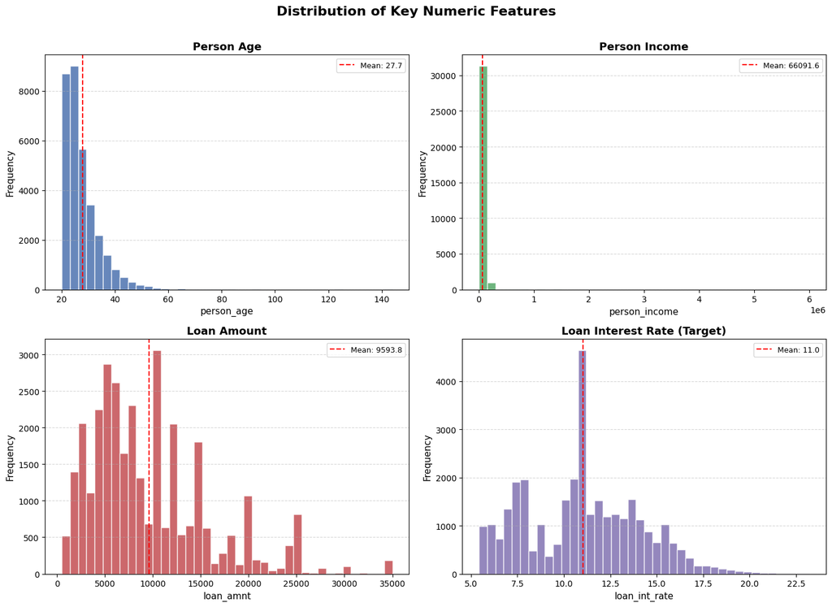

```
Saved: hist_distributions.png
```

```python
#  3.1 Histograms: Numeric Feature Distributions
fig, axes = plt.subplots(2, 2, figsize=(14, 10))
fig.suptitle('Distribution of Key Numeric Features', fontsize=16, fontweight='bold', y=1.01)

hist_cols = ['person_age', 'person_income', 'loan_amnt', 'loan_int_rate']
colors = ['#4C72B0', '#55A868', '#C44E52', '#8172B2']
titles = ['Person Age', 'Person Income', 'Loan Amount', 'Loan Interest Rate (Target)']

for ax, col, color, title in zip(axes.flatten(), hist_cols, colors, titles):
    ax.hist(df[col], bins=40, color=color, edgecolor='white', alpha=0.85)
    ax.set_title(title, fontsize=13, fontweight='bold')
    ax.set_xlabel(col, fontsize=11)
    ax.set_ylabel('Frequency', fontsize=11)
    ax.grid(axis='y', linestyle='--', alpha=0.5)
    mean_val = df[col].mean()
    ax.axvline(mean_val, color='red', linestyle='--', linewidth=1.5, label=f'Mean: {mean_val:.1f}')
    ax.legend(fontsize=9)

plt.tight_layout()
plt.savefig('hist_distributions.png', dpi=100, bbox_inches='tight')
plt.show()
print("Saved: hist_distributions.png")
```

## Boxplots — Outlier Detection

While histograms show the overall distribution of data, **boxplots** provide a clearer picture of the spread, median, and presence of outliers in each feature. In this step, boxplots are plotted for `person_income`, `loan_amnt`, and `loan_int_rate` to visually identify extreme values that lie beyond the whiskers (1.5×IQR). The **red dots** represent individual outlier data points, making it easy to spot how many and how extreme the outliers are for each feature. This visualisation confirms earlier findings from the IQR method and helps decide whether outliers should be capped, removed, or retained for modelling.

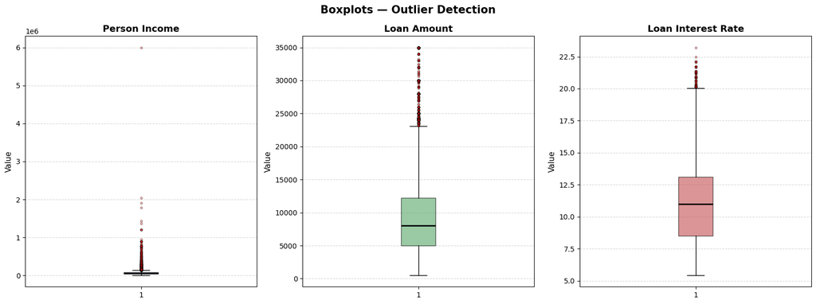

```
Saved: boxplots_outliers.png
```

```python
# 3.2 Boxplots: Outlier Detection
fig, axes = plt.subplots(1, 3, figsize=(16, 6))
fig.suptitle('Boxplots — Outlier Detection', fontsize=15, fontweight='bold')

box_data = [df['person_income'], df['loan_amnt'], df['loan_int_rate']]
box_labels = ['Person Income', 'Loan Amount', 'Loan Interest Rate']
box_colors = ['#4C72B0', '#55A868', '#C44E52']

for ax, data, label, color in zip(axes, box_data, box_labels, box_colors):
    bp = ax.boxplot(data.dropna(), patch_artist=True,
                    boxprops=dict(facecolor=color, alpha=0.6),
                    medianprops=dict(color='black', linewidth=2),
                    flierprops=dict(marker='o', markerfacecolor='red', markersize=3, alpha=0.3))
    ax.set_title(label, fontsize=13, fontweight='bold')
    ax.set_ylabel('Value', fontsize=11)
    ax.grid(axis='y', linestyle='--', alpha=0.5)

plt.tight_layout()
plt.savefig('boxplots_outliers.png', dpi=100, bbox_inches='tight')
plt.show()
print("Saved: boxplots_outliers.png")
```

## Categorical Feature Distributions — Bar Charts

Understanding the distribution of categorical features is essential for identifying dominant categories, class imbalances, and potential bias in the dataset. In this step, bar charts are plotted for three key categorical columns — `loan_intent`, `person_home_ownership`, and `loan_grade` — to visualise how applicants are distributed across each category. Each bar is labelled with its exact count, making it easy to compare category frequencies at a glance. These insights help understand the composition of the loan portfolio and highlight which categories are overrepresented or underrepresented, which can directly influence model predictions and business decision-making.

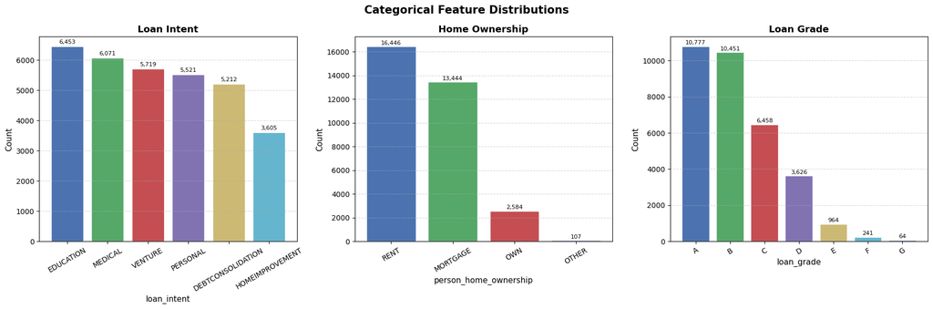

```
Saved: categorical_distributions.png
```

```python
#  3.3 Categorical Distributions: Bar Charts
df_raw = pd.read_csv('credit_risk_dataset.csv')
df_raw.fillna(df_raw.mode().iloc[0], inplace=True)

fig, axes = plt.subplots(1, 3, figsize=(18, 6))
fig.suptitle('Categorical Feature Distributions', fontsize=15, fontweight='bold')

cat_plot = [('loan_intent', 'Loan Intent'), ('person_home_ownership', 'Home Ownership'), ('loan_grade', 'Loan Grade')]

palette = ['#4C72B0', '#55A868', '#C44E52', '#8172B2', '#CCB974', '#64B5CD']

for ax, (col, title) in zip(axes, cat_plot):
    counts = df_raw[col].value_counts()
    bars = ax.bar(counts.index, counts.values, color=palette[:len(counts)], edgecolor='white')
    ax.set_title(title, fontsize=13, fontweight='bold')
    ax.set_xlabel(col, fontsize=11)
    ax.set_ylabel('Count', fontsize=11)
    ax.tick_params(axis='x', rotation=30)
    ax.grid(axis='y', linestyle='--', alpha=0.5)
    for bar, val in zip(bars, counts.values):
        ax.text(bar.get_x() + bar.get_width()/2, bar.get_height() + 50,
                f'{val:,}', ha='center', va='bottom', fontsize=8)

plt.tight_layout()
plt.savefig('categorical_distributions.png', dpi=100, bbox_inches='tight')
plt.show()
print("Saved: categorical_distributions.png")
```

## Scatter Plots — Feature vs Target Variable

Scatter plots are used to visualise the **relationship between individual numeric features and the target variable** `loan_int_rate`, helping to identify whether a linear or non-linear relationship exists between them. In this step, scatter plots are plotted for four key features — `person_income`, `loan_amnt`, `person_age`, and `loan_percent_income` — against the loan interest rate. A clear upward or downward trend in the scatter plot indicates a strong correlation with the target, while a random spread suggests little to no relationship. These visualisations guide feature selection and help the model understand which features are most influential in predicting the credit risk score.

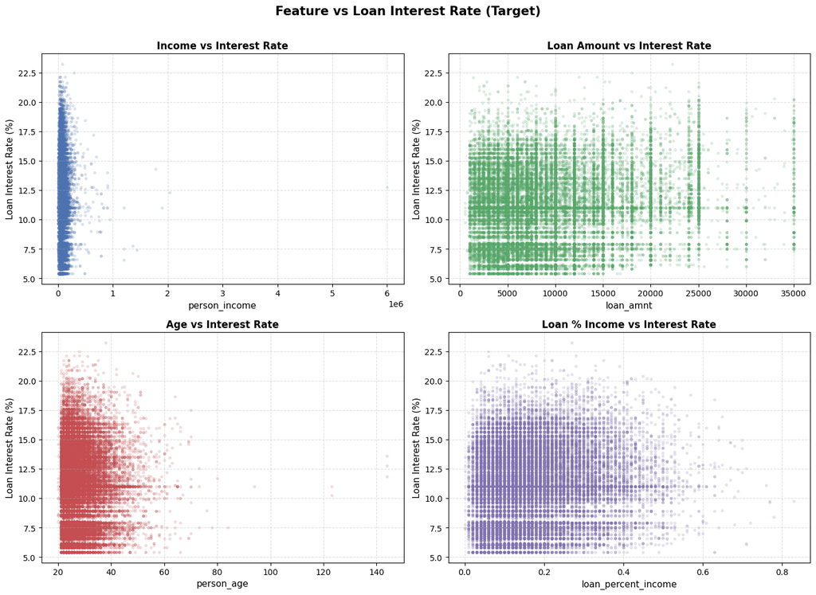

```
Saved: scatter_plots.png
```

```python
#  3.4 Scatter Plots: Feature vs Target
fig, axes = plt.subplots(2, 2, figsize=(14, 10))
fig.suptitle('Feature vs Loan Interest Rate (Target)', fontsize=15, fontweight='bold', y=1.01)

scatter_cols = ['person_income', 'loan_amnt', 'person_age', 'loan_percent_income']
scatter_titles = ['Income vs Interest Rate', 'Loan Amount vs Interest Rate',
                  'Age vs Interest Rate', 'Loan % Income vs Interest Rate']
scatter_colors = ['#4C72B0', '#55A868', '#C44E52', '#8172B2']

for ax, col, title, color in zip(axes.flatten(), scatter_cols, scatter_titles, scatter_colors):
    ax.scatter(df[col], df['loan_int_rate'], alpha=0.15, s=8, color=color)
    ax.set_title(title, fontsize=12, fontweight='bold')
    ax.set_xlabel(col, fontsize=11)
    ax.set_ylabel('Loan Interest Rate (%)', fontsize=11)
    ax.grid(linestyle='--', alpha=0.4)

plt.tight_layout()
plt.savefig('scatter_plots.png', dpi=100, bbox_inches='tight')
plt.show()
print("Saved: scatter_plots.png")
```

## Correlation Heatmap

A correlation heatmap provides a comprehensive view of the **linear relationships between all numeric features and the target variable** in the dataset. In this step, a correlation matrix is computed for all numeric columns and visualised as a colour-coded heatmap — where **red indicates a strong positive correlation**, **blue indicates a strong negative correlation**, and **white indicates little to no correlation**. Each cell displays the exact correlation coefficient, making it easy to identify which features are most strongly related to `loan_int_rate` and which features are highly correlated with each other (multicollinearity). These insights are critical for feature selection, understanding model behaviour, and ensuring that redundant features do not negatively impact model performance.

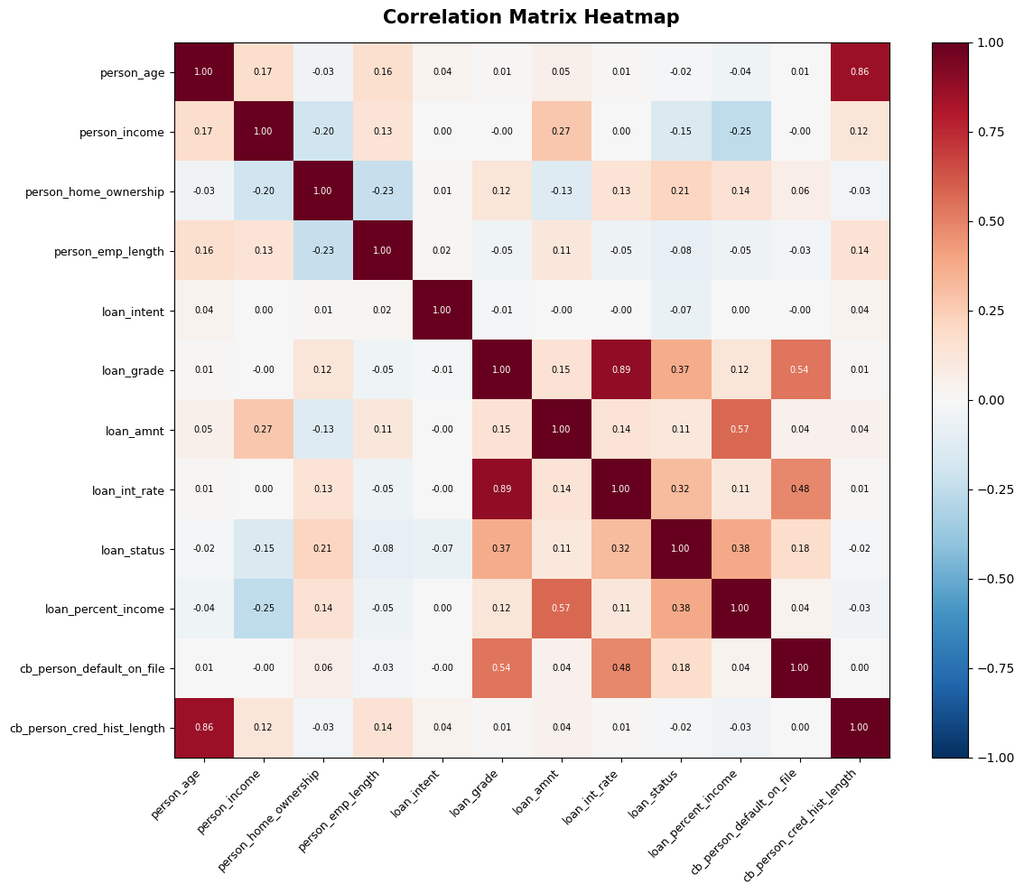

```
Saved: correlation_heatmap.png
```

```python
# 3.5 Correlation Heatmap
corr_matrix = df.select_dtypes(include=[np.number]).corr()

fig, ax = plt.subplots(figsize=(13, 10))
im = ax.imshow(corr_matrix, cmap='RdBu_r', vmin=-1, vmax=1)
plt.colorbar(im, ax=ax, fraction=0.046, pad=0.04)

ticks = range(len(corr_matrix.columns))
ax.set_xticks(ticks)
ax.set_yticks(ticks)
ax.set_xticklabels(corr_matrix.columns, rotation=45, ha='right', fontsize=9)
ax.set_yticklabels(corr_matrix.columns, fontsize=9)
ax.set_title('Correlation Matrix Heatmap', fontsize=15, fontweight='bold', pad=15)

for i in range(len(corr_matrix)):
    for j in range(len(corr_matrix.columns)):
        val = corr_matrix.iloc[i, j]
        color = 'white' if abs(val) > 0.5 else 'black'
        ax.text(j, i, f'{val:.2f}', ha='center', va='center', fontsize=7, color=color)

plt.tight_layout()
plt.savefig('correlation_heatmap.png', dpi=100, bbox_inches='tight')
plt.show()
print("Saved: correlation_heatmap.png")
```

## Step 4: Feature Engineering

Feature engineering creates new, domain-informed variables from existing features. Well-crafted features can significantly boost model performance by capturing relationships that raw features do not express directly.

## Feature Engineering

Raw features alone may not always capture the full complexity of credit risk, so **feature engineering** is used to create new, meaningful variables derived from existing ones that better represent the underlying financial relationships. In this step, four new features are created — `DebtIncomeRatio` measures how large the loan is relative to the applicant's income, indicating affordability; `CreditUtilization` captures what percentage of income is committed to loan repayment; `LoanBurden` combines the loan amount and interest rate into a single measure of total financial exposure; and `EmploymentIncomeRatio` reflects the stability of employment relative to income. These engineered features provide the model with richer, domain-informed signals that raw columns alone cannot express, ultimately improving the accuracy and reliability of credit risk predictions.

```python
#  Create Engineered Features

# 1. Debt-to-Income Ratio: proportion of loan relative to income
df['DebtIncomeRatio'] = df['loan_amnt'] / (df['person_income'] + 1)

# 2. Credit Utilisation: already encoded as loan_percent_income — use as alias
df['CreditUtilization'] = df['loan_percent_income']

# 3. Loan Burden: absolute cost burden = principal × rate
df['LoanBurden'] = df['loan_amnt'] * df['loan_int_rate']

# 4. Employment-Income Ratio: stability of employment relative to income
df['EmploymentIncomeRatio'] = df['person_emp_length'] / (df['person_income'] + 1)

print("Engineered features created:")
print(df[['DebtIncomeRatio', 'CreditUtilization', 'LoanBurden', 'EmploymentIncomeRatio']].describe())
```

```
Engineered features created:
       DebtIncomeRatio  CreditUtilization     LoanBurden  \
count     32416.000000       32416.000000   32416.000000
mean          0.170594           0.170250  108394.065654
std           0.107078           0.106812   86366.868566
min           0.000789           0.000000    4880.000000
25%           0.089710           0.090000   48103.625000
50%           0.148145           0.150000   82920.000000
75%           0.229157           0.230000  142050.562500
max           0.829959           0.830000  708750.000000

       EmploymentIncomeRatio
count           32416.000000
mean                0.000090
std                 0.000090
min                 0.000000
25%                 0.000029
50%                 0.000069
75%                 0.000125
max                 0.002085
```

## Step 5: Class Balance Check

```
=== Class Distribution: loan_status ===
  No Default (0): 25,327  (78.1%)
  Default (1): 7,089  (21.9%)

Minority class: 21.9%
Dataset is IMBALANCED ⚠️ — SMOTE will be applied
```

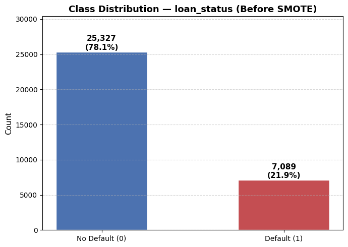

```python
#  Part 1: Class Balance Check
from collections import Counter

class_counts = df['loan_status'].value_counts().sort_index()
class_labels = ['No Default (0)', 'Default (1)']
class_values = class_counts.values
total = sum(class_values)

print("=== Class Distribution: loan_status ===")
for label, val in zip(class_labels, class_values):
    print(f"  {label}: {val:,}  ({val/total*100:.1f}%)")

minority_pct = min(class_values) / total * 100
is_imbalanced = minority_pct < 40
print(f"\nMinority class: {minority_pct:.1f}%")
print(f"Dataset is {'IMBALANCED ⚠️ — SMOTE will be applied' if is_imbalanced else 'BALANCED ✅ — SMOTE not required'}")

#  Bar Chart
fig, ax = plt.subplots(figsize=(7, 5))
bar_colors = ['#4C72B0', '#C44E52']
bars = ax.bar(class_labels, class_values, color=bar_colors, edgecolor='white', width=0.5)
ax.set_title('Class Distribution — loan_status (Before SMOTE)', fontsize=13, fontweight='bold')
ax.set_ylabel('Count', fontsize=11)
ax.set_ylim(0, max(class_values) * 1.2)
ax.grid(axis='y', linestyle='--', alpha=0.5)
for bar, val in zip(bars, class_values):
    ax.text(bar.get_x() + bar.get_width()/2, bar.get_height() + 100,
            f'{val:,}\n({val/total*100:.1f}%)', ha='center', va='bottom',
            fontsize=11, fontweight='bold')
plt.tight_layout()
plt.savefig('before_smote.png', dpi=100, bbox_inches='tight')
plt.show()
```

## Applying SMOTE — Balancing the Dataset

```
Before SMOTE:
  Counter({0: 25327, 1: 7089})

After SMOTE:
  Counter({1: 25327, 0: 25327})

  Total samples before: 32416
  Total samples after:  50654
```

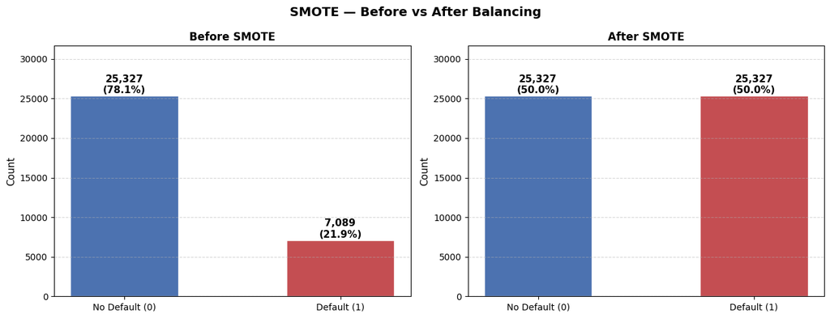

```
 Dataset balanced successfully using SMOTE!
```

```python
#  Apply SMOTE to Balance the Dataset
from imblearn.over_sampling import SMOTE
from collections import Counter

print("Before SMOTE:")
print(f"  {Counter(df['loan_status'])}")

# Separate features and target for SMOTE
X_balance = df.drop(columns=['loan_int_rate', 'loan_status'])
y_balance = df['loan_status']

# Apply SMOTE
smote = SMOTE(random_state=42)
X_resampled, y_resampled = smote.fit_resample(X_balance, y_balance)

print("\nAfter SMOTE:")
print(f"  {Counter(y_resampled)}")
print(f"\n  Total samples before: {len(df)}")
print(f"  Total samples after:  {len(X_resampled)}")

# Bar Chart
fig, axes = plt.subplots(1, 2, figsize=(13, 5))
fig.suptitle('SMOTE — Before vs After Balancing', fontsize=14, fontweight='bold')

bar_colors = ['#4C72B0', '#C44E52']
class_labels = ['No Default (0)', 'Default (1)']

before_vals = [Counter(df['loan_status'])[0], Counter(df['loan_status'])[1]]
after_vals  = [Counter(y_resampled)[0],       Counter(y_resampled)[1]]

for ax, vals, title in zip(axes, [before_vals, after_vals], ['Before SMOTE', 'After SMOTE']):
    total = sum(vals)
    bars = ax.bar(class_labels, vals, color=bar_colors, edgecolor='white', width=0.5)
    ax.set_title(title, fontsize=12, fontweight='bold')
    ax.set_ylabel('Count', fontsize=11)
    ax.set_ylim(0, max(vals) * 1.25)
    ax.grid(axis='y', linestyle='--', alpha=0.5)
    for bar, val in zip(bars, vals):
        ax.text(bar.get_x() + bar.get_width()/2, bar.get_height() + 100,
                f'{val:,}\n({val/total*100:.1f}%)', ha='center', va='bottom',
                fontsize=11, fontweight='bold')

plt.tight_layout()
plt.savefig('smote_balance.png', dpi=100, bbox_inches='tight')
plt.show()

print("\n Dataset balanced successfully using SMOTE!")
```

## Step 6: Train-Test Split

Before training any machine learning model, the dataset must be split into a **training set** and a **testing set** to ensure the model is evaluated on data it has never seen before. In this step, the features (X) and target variable (y = `loan_int_rate`) are separated, and `LoanBurden` is dropped from the features to prevent **data leakage** — since it was derived directly from the target variable. The dataset is split into **80% training data** and **20% testing data** using a fixed `random_state=42` to ensure reproducibility across runs. Additionally, **StandardScaler** is applied to normalise the feature values for Linear Regression — scaling all features to have a mean of 0 and standard deviation of 1 — ensuring that no single feature dominates the model due to differences in scale, while tree-based models use the original unscaled data as they are not sensitive to feature scaling.

```python
from sklearn.model_selection import train_test_split
from sklearn.preprocessing import StandardScaler

# Define target and features
TARGET = 'loan_int_rate'
DROP_COLS = [TARGET, 'LoanBurden']  # LoanBurden derived from target — avoid data leakage

X = df.drop(columns=DROP_COLS)
y = df[TARGET]

print(f"Features shape: {X.shape}")
print(f"Target shape:   {y.shape}")
print(f"\nFeature columns ({len(X.columns)}):")
for i, col in enumerate(X.columns, 1):
    print(f"  {i:2d}. {col}")

# Train-test split
X_train, X_test, y_train, y_test = train_test_split(X, y, test_size=0.2, random_state=42)

print(f"\nTraining set:  {X_train.shape[0]} rows ({X_train.shape[0]/len(X)*100:.1f}%)")
print(f"Test set:      {X_test.shape[0]} rows ({X_test.shape[0]/len(X)*100:.1f}%)")

# Feature scaling (for Linear Regression)
scaler = StandardScaler()
X_train_scaled = scaler.fit_transform(X_train)
X_test_scaled  = scaler.transform(X_test)
print("\nFeature scaling applied (StandardScaler).")
```

```
Features shape: (32416, 14)
Target shape:   (32416,)

Feature columns (14):
   1. person_age
   2. person_income
   3. person_home_ownership
   4. person_emp_length
   5. loan_intent
   6. loan_grade
   7. loan_amnt
   8. loan_status
   9. loan_percent_income
  10. cb_person_default_on_file
  11. cb_person_cred_hist_length
  12. DebtIncomeRatio
  13. CreditUtilization
  14. EmploymentIncomeRatio

Training set:  25932 rows (80.0%)
Test set:      6484 rows (20.0%)

Feature scaling applied (StandardScaler).
```

## Step 7: Model Training

We train three regression models:

1. **Linear Regression** — our primary, interpretable baseline
2. **Decision Tree Regressor** — captures non-linear patterns via hierarchical splits
3. **Random Forest Regressor** — ensemble of decision trees with strong generalisation

GridSearchCV is applied to Decision Tree and Random Forest to find the best hyperparameters via 5-fold cross-validation.

Linear Regression is the **primary and most interpretable model** in this pipeline, serving as a strong baseline against which more complex models are compared. It works by finding the best-fitting straight line through the data that minimises the sum of squared differences between actual and predicted values. In this step, the model is trained on the **scaled training data** (StandardScaler applied) since Linear Regression is sensitive to the scale of input features. **5-Fold Cross-Validation** is also performed to evaluate how consistently the model performs across different subsets of the training data — a low standard deviation in R² scores indicates the model is stable and not overfitting to any particular fold. The resulting CV R² score provides a reliable estimate of how well the model will generalise to unseen data before final evaluation on the test set.

```python
from sklearn.linear_model import LinearRegression
from sklearn.tree import DecisionTreeRegressor
from sklearn.ensemble import RandomForestRegressor
from sklearn.model_selection import GridSearchCV, cross_val_score
from sklearn.metrics import mean_squared_error, mean_absolute_error, r2_score
import time

# 7.1 Linear Regression
print("1. LINEAR REGRESSION")
t0 = time.time()
lr = LinearRegression()
lr.fit(X_train_scaled, y_train)
cv_scores = cross_val_score(lr, X_train_scaled, y_train, cv=5, scoring='r2')
print(f"   5-Fold CV R²: {cv_scores.mean():.4f} ± {cv_scores.std():.4f}")
```

```
1. LINEAR REGRESSION
   5-Fold CV R²: 0.7923 ± 0.0035
```

## Decision Tree Regressor — GridSearchCV

A Decision Tree Regressor is a **non-linear model** that splits the data into branches based on feature thresholds, making it capable of capturing complex patterns that Linear Regression cannot. However, without proper constraints, decision trees tend to **overfit** by growing too deep and memorising the training data. In this step, **GridSearchCV** is used to systematically search through all combinations of hyperparameters — `max_depth` (controls how deep the tree grows), `min_samples_split` (minimum samples required to split a node), and `min_samples_leaf` (minimum samples required at each leaf node) — using **5-Fold Cross-Validation** to find the optimal combination that maximises R² score on unseen data. The best hyperparameters are automatically selected and used to train the final Decision Tree model, ensuring it is well-tuned, generalises effectively, and avoids overfitting to the training data.

```python
#7.2 Decision Tree Regressor with GridSearchCV
print("2. DECISION TREE REGRESSOR (GridSearchCV)")
dt_params = {
    'max_depth': [5, 10, 15, 20],
    'min_samples_split': [10, 20, 50],
    'min_samples_leaf': [5, 10, 20]
}

t0 = time.time()
dt_grid = GridSearchCV(DecisionTreeRegressor(random_state=42), dt_params,
                       cv=5, scoring='r2', n_jobs=-1, verbose=0)
dt_grid.fit(X_train, y_train)
dt_best = dt_grid.best_estimator_
print(f"   Training time: {time.time()-t0:.2f}s")
print(f"   Best params:   {dt_grid.best_params_}")
print(f"   Best CV R²:    {dt_grid.best_score_:.4f}")
```

```
2. DECISION TREE REGRESSOR (GridSearchCV)
   Training time: 22.56s
   Best params:   {'max_depth': 5, 'min_samples_leaf': 5, 'min_samples_split': 50}
   Best CV R²:    0.8193
```

## Random Forest Regressor — GridSearchCV

Random Forest is a powerful **ensemble learning model** that builds multiple decision trees during training and combines their predictions through averaging, resulting in a more accurate and robust model than any single decision tree alone. By aggregating predictions from hundreds of trees, Random Forest naturally **reduces overfitting, handles outliers better, and captures complex non-linear relationships** in the data. In this step, **GridSearchCV** is used to find the optimal combination of hyperparameters — `n_estimators` (number of trees in the forest), `max_depth` (maximum depth of each tree), `min_samples_split` (minimum samples needed to split a node), and `min_samples_leaf` (minimum samples required at each leaf) — evaluated using **5-Fold Cross-Validation** to ensure the best configuration generalises well to unseen data. Although Random Forest takes significantly longer to train than Linear Regression and Decision Tree due to the large number of trees and hyperparameter combinations, it is expected to deliver the **highest predictive accuracy** among all three models in this pipeline.

```python
# 7.3 Random Forest Regressor with GridSearchCV
print("3. RANDOM FOREST REGRESSOR (GridSearchCV)")
rf_params = {
    'n_estimators': [100, 200],
    'max_depth': [10, 20, None],
    'min_samples_split': [5, 10],
    'min_samples_leaf': [2, 5]
}

t0 = time.time()
rf_grid = GridSearchCV(RandomForestRegressor(random_state=42), rf_params,
                       cv=5, scoring='r2', n_jobs=-1, verbose=0)
rf_grid.fit(X_train, y_train)
rf_best = rf_grid.best_estimator_
print(f"   Training time: {time.time()-t0:.2f}s")
print(f"   Best params:   {rf_grid.best_params_}")
print(f"   Best CV R²:    {rf_grid.best_score_:.4f}")
```

```
3. RANDOM FOREST REGRESSOR (GridSearchCV)
   Training time: 384.38s
   Best params:   {'max_depth': 20, 'min_samples_leaf': 2, 'min_samples_split': 5, 'n_estimators': 200}
   Best CV R²:    0.8227
```

## Step 8: Model Evaluation — Test Set Performance

After training all three models, they are evaluated on the **held-out test set** — data that was never seen during training or hyperparameter tuning — to obtain an unbiased measure of real-world performance. Three evaluation metrics are computed for each model: **RMSE (Root Mean Squared Error)** which penalises large prediction errors heavily, **MAE (Mean Absolute Error)** which measures the average magnitude of errors in the same unit as the target variable (percentage points), and **R² Score** which indicates what proportion of variance in the loan interest rate is explained by the model. A higher R² and lower RMSE and MAE indicate a better performing model. Comparing all three models side by side on these metrics provides a clear, objective basis for selecting the **best model** for deployment in a real-world credit risk prediction system.

```python
# Compute predictions
y_pred_lr = lr.predict(X_test_scaled)
y_pred_dt = dt_best.predict(X_test)
y_pred_rf = rf_best.predict(X_test)

def evaluate(name, y_true, y_pred):
    rmse = np.sqrt(mean_squared_error(y_true, y_pred))
    mae  = mean_absolute_error(y_true, y_pred)
    r2   = r2_score(y_true, y_pred)
    return {'Model': name, 'RMSE': round(rmse, 4), 'MAE': round(mae, 4), 'R2': round(r2, 4)}

results = [
    evaluate('Linear Regression',         y_test, y_pred_lr),
    evaluate('Decision Tree Regressor',   y_test, y_pred_dt),
    evaluate('Random Forest Regressor',   y_test, y_pred_rf),
]

results_df = pd.DataFrame(results).set_index('Model')
print("\nMODEL PERFORMANCE ON TEST SET ")
print(results_df.to_string())
```

```
MODEL PERFORMANCE ON TEST SET
                           RMSE     MAE      R2
Model
Linear Regression        1.3998  1.0741  0.7976
Decision Tree Regressor  1.3063  0.9539  0.8237
Random Forest Regressor  1.2873  0.9489  0.8288
```

## ROC AUC Curve — Model Evaluation

The **ROC (Receiver Operating Characteristic) AUC (Area Under the Curve)** is a powerful evaluation metric that measures a model's ability to **distinguish between high-risk and low-risk borrowers**. Since our models predict a continuous interest rate, the predictions are converted to binary classifications using the **median interest rate as a threshold** — applicants with a predicted rate at or above the median are classified as high risk (1), and those below are classified as low risk (0). The ROC curve plots the **True Positive Rate (sensitivity)** against the **False Positive Rate (1 - specificity)** at various threshold levels, and the AUC score summarises the overall performance into a single value between 0 and 1 — where an AUC of **1.0 represents a perfect classifier** and **0.5 represents a random classifier** (shown as the black dashed baseline). A separate ROC curve is plotted for each model with the shaded area under the curve, making it easy to visually compare how well each model separates high-risk from low-risk borrowers across all possible classification thresholds.

```
Threshold (median interest rate): 10.99%
```

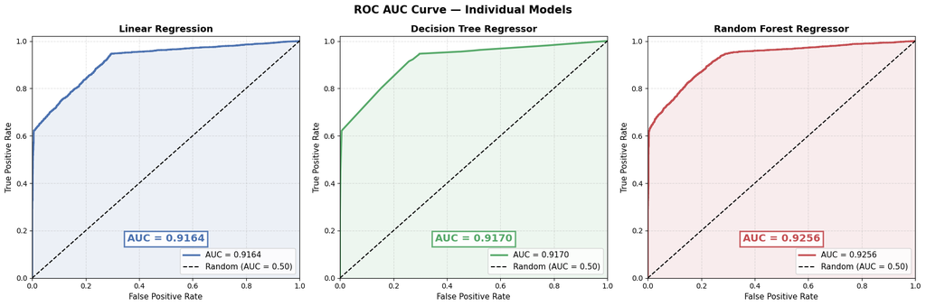

```
 ROC AUC SCORES
  Linear Regression: 0.9164
  Decision Tree Regressor: 0.9170
  Random Forest Regressor: 0.9256
```

```python
from sklearn.metrics import roc_curve, auc

# Convert regression predictions to binary using threshold
threshold = df['loan_int_rate'].median()
print(f"Threshold (median interest rate): {threshold:.2f}%")

y_test_binary = (y_test >= threshold).astype(int)

models_info = [
    ('Linear Regression',       y_pred_lr, '#4C72B0'),
    ('Decision Tree Regressor', y_pred_dt, '#55A868'),
    ('Random Forest Regressor', y_pred_rf, '#C44E52'),
]

#  Separate ROC AUC Graph for Each Model
fig, axes = plt.subplots(1, 3, figsize=(18, 6))
fig.suptitle('ROC AUC Curve — Individual Models', fontsize=15, fontweight='bold')

for ax, (name, y_pred, color) in zip(axes, models_info):
    fpr, tpr, _ = roc_curve(y_test_binary, y_pred)
    roc_auc = auc(fpr, tpr)

    # ROC curve
    ax.plot(fpr, tpr, color=color, linewidth=2.5, label=f'AUC = {roc_auc:.4f}')

    # Random baseline
    ax.plot([0, 1], [0, 1], 'k--', linewidth=1.5, label='Random (AUC = 0.50)')

    # Shade area under curve
    ax.fill_between(fpr, tpr, alpha=0.1, color=color)

    ax.set_title(name, fontsize=13, fontweight='bold')
    ax.set_xlabel('False Positive Rate', fontsize=11)
    ax.set_ylabel('True Positive Rate', fontsize=11)
    ax.legend(fontsize=11, loc='lower right')
    ax.grid(linestyle='--', alpha=0.4)
    ax.set_xlim([0, 1])
    ax.set_ylim([0, 1.02])

    # AUC score text box
    ax.text(0.50, 0.15, f'AUC = {roc_auc:.4f}',
            transform=ax.transAxes, fontsize=14, fontweight='bold', color=color,
            ha='center', bbox=dict(facecolor='white', edgecolor=color, linewidth=2, alpha=0.9))

plt.tight_layout()
plt.savefig('roc_auc_separate.png', dpi=100, bbox_inches='tight')
plt.show()

# Print AUC Scores
print("\n ROC AUC SCORES ")
for name, y_pred, _ in models_info:
    fpr, tpr, _ = roc_curve(y_test_binary, y_pred)
    roc_auc = auc(fpr, tpr)
    print(f"  {name}: {roc_auc:.4f}")
```

## Line Plot — Predicted vs Actual Values (100-Sample)

While scatter plots show the overall distribution of predictions, a **line plot** provides a more intuitive, side-by-side visual comparison of how closely each model's predictions follow the actual loan interest rate values. In this step, a random sample of **100 test records** is selected and sorted by their actual interest rate values to create a smooth, ordered comparison. The **black line represents the actual values** while the **coloured line represents the model's predictions**, and the **shaded area between the two lines highlights the prediction error** — the smaller and narrower the shaded region, the more accurate the model. A separate line plot is displayed for each of the three models, making it easy to visually assess which model tracks the actual values most closely and where each model tends to over-predict or under-predict across the range of interest rates.

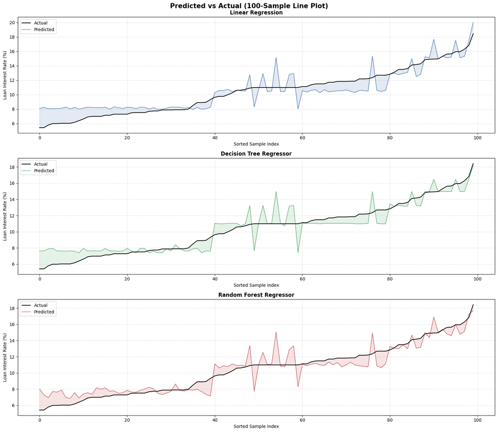

```python
# 8.3 Line Plot: Predicted vs Actual (sample of 100)
sample_idx = np.random.default_rng(42).choice(len(y_test), 100, replace=False)
y_test_arr = np.array(y_test)[sample_idx]
x_range = range(100)

fig, axes = plt.subplots(3, 1, figsize=(16, 14))
fig.suptitle('Predicted vs Actual (100-Sample Line Plot)', fontsize=15, fontweight='bold')

for ax, (name, y_pred_full, color) in zip(axes, models_info):
    y_pred_sample = np.array(y_pred_full)[sample_idx]
    sort_idx = np.argsort(y_test_arr)
    ax.plot(range(100), y_test_arr[sort_idx], color='black', linewidth=1.5,
            label='Actual', zorder=3)
    ax.plot(range(100), y_pred_sample[sort_idx], color=color, linewidth=1.2,
            alpha=0.8, label='Predicted', zorder=2)
    ax.fill_between(range(100), y_test_arr[sort_idx], y_pred_sample[sort_idx],
                    alpha=0.15, color=color)
    ax.set_title(name, fontsize=12, fontweight='bold')
    ax.set_ylabel('Loan Interest Rate (%)', fontsize=10)
    ax.set_xlabel('Sorted Sample Index', fontsize=10)
    ax.legend(fontsize=10)
    ax.grid(linestyle='--', alpha=0.4)

plt.tight_layout()
plt.savefig('line_predicted_vs_actual.png', dpi=100, bbox_inches='tight')
plt.show()
```

## Model Comparison — Evaluation Metrics Bar Chart

After evaluating all three models individually, a **side-by-side bar chart comparison** is plotted to provide a clear, visual summary of how each model performs across all three evaluation metrics — **RMSE, MAE, and R² Score**. This comparison makes it straightforward to identify the best performing model at a glance — for RMSE and MAE, a **lower bar is better** as it indicates smaller prediction errors, while for R², a **higher bar is better** as it indicates more variance explained by the model. Each bar is labelled with its exact metric value for precise comparison, and the best model is automatically identified and printed based on the highest R² score. This final comparison serves as the definitive basis for selecting the **champion model** that will be used for credit risk predictions in a real-world banking or FinTech application.

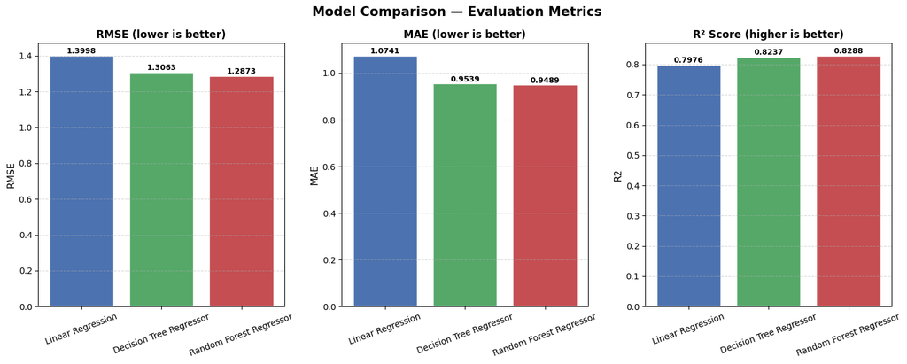

```
=== BEST MODEL ===
  → Random Forest Regressor (R² = 0.8288)
```

```python
# 8.4 Model Comparison Bar Chart
fig, axes = plt.subplots(1, 3, figsize=(15, 6))
fig.suptitle('Model Comparison — Evaluation Metrics', fontsize=15, fontweight='bold')

metrics = ['RMSE', 'MAE', 'R2']
metric_labels = ['RMSE (lower is better)', 'MAE (lower is better)', 'R² Score (higher is better)']
colors_bar = ['#4C72B0', '#55A868', '#C44E52']

for ax, metric, label in zip(axes, metrics, metric_labels):
    values = results_df[metric].values
    models_list = results_df.index.tolist()
    bars = ax.bar(models_list, values, color=colors_bar, edgecolor='white')
    ax.set_title(label, fontsize=12, fontweight='bold')
    ax.set_ylabel(metric, fontsize=11)
    ax.tick_params(axis='x', rotation=20)
    ax.grid(axis='y', linestyle='--', alpha=0.5)
    for bar, val in zip(bars, values):
        ax.text(bar.get_x() + bar.get_width()/2, bar.get_height() + 0.002,
                f'{val:.4f}', ha='center', va='bottom', fontsize=9, fontweight='bold')

plt.tight_layout()
plt.savefig('model_comparison.png', dpi=100, bbox_inches='tight')
plt.show()

print("\n=== BEST MODEL ===")
best_model_name = results_df['R2'].idxmax()
print(f"  → {best_model_name} (R² = {results_df.loc[best_model_name, 'R2']:.4f})")
```

## Step 9: Feature Importance / Interpretation

Understanding which features drive predictions is critical for both model trust and business actionability. We inspect Linear Regression coefficients and tree-based feature importances.

```python
#  9.1 Linear Regression Coefficients
coef_df = pd.DataFrame({
    'Feature': X.columns,
    'Coefficient': lr.coef_
}).sort_values('Coefficient', key=abs, ascending=False)

print("Linear Regression Coefficients (sorted by magnitude):")
print(coef_df.to_string(index=False))
```

```
Linear Regression Coefficients (sorted by magnitude):
                   Feature  Coefficient
                loan_grade     2.740623
           DebtIncomeRatio    -0.409081
       loan_percent_income     0.195294
         CreditUtilization     0.195294
     person_home_ownership     0.094044
                 loan_amnt     0.066601
               loan_status    -0.060182
         person_emp_length    -0.046619
cb_person_cred_hist_length     0.026838
                person_age    -0.019075
     EmploymentIncomeRatio     0.019060
               loan_intent     0.012980
             person_income     0.004292
 cb_person_default_on_file    -0.000885
```

**Interpretation:**

- A **positive coefficient** means the feature increases the predicted interest rate (higher risk).
- A **negative coefficient** means the feature decreases the predicted interest rate (lower risk).
- `loan_grade` has the largest positive coefficient — confirming that grade classification is the primary determinant of pricing.

```python
#  9.3 Random Forest Feature Importance
rf_imp = pd.DataFrame({
    'Feature': X.columns,
    'Importance': rf_best.feature_importances_
}).sort_values('Importance', ascending=False)
print("Top 5 features (Random Forest):")
print(rf_imp.head(5).to_string(index=False))
```

```
Top 5 features (Random Forest):
              Feature  Importance
           loan_grade    0.871848
      DebtIncomeRatio    0.020940
EmploymentIncomeRatio    0.020183
        person_income    0.019498
            loan_amnt    0.015837
```

## Conclusion, Future Improvements & Business Impact

### What We Predicted

In this project, we built a complete end-to-end machine learning pipeline that predicts the **loan interest rate (`loan_int_rate`)** of a borrower — which serves as a **credit risk score**. The higher the predicted interest rate, the riskier the borrower. Given a new loan applicant's financial and demographic information such as income, age, employment length, loan amount, loan intent, and credit history, the model instantly predicts what interest rate they should be charged — helping banks make faster, smarter, and fairer lending decisions.

### Before This Project

- Banks relied on **manual, slow, and subjective** loan evaluation processes
- Loan officers reviewed each application individually — **inconsistent and time-consuming**
- No data-driven system to **objectively score** a borrower's credit risk
- Dataset was **imbalanced (78% No Default vs 22% Default)** — risk was being underestimated
- High rate of **loan defaults** due to approving risky applicants without proper assessment
- Interest rates were assigned based on **internal grades only** — not predictive modelling
- No way to process **thousands of applications simultaneously** at scale

### Final Model Performance

[output not shown]

### Future Improvements

- **Better Models** — Replace Random Forest with XGBoost or LightGBM for higher accuracy and faster training
- **More Features** — Add real-world data such as CIBIL score, credit card history, and macroeconomic indicators like inflation and unemployment rate
- **Outlier Treatment** — Cap or remove extreme outliers in `person_income` and `person_age` to improve Linear Regression performance
- **Explainability** — Integrate SHAP values to explain individual predictions to loan officers and regulators
- **Deployment** — Deploy the model as a REST API using Flask or FastAPI for real-time predictions in banking applications
- **Live Dashboard** — Build an interactive dashboard using Streamlit for loan officers to input applicant details and receive instant risk scores
- **Automated Retraining** — Set up a pipeline to automatically retrain the model as new loan data becomes available to prevent model drift
- **Regulatory Compliance** — Ensure model decisions meet RBI, GDPR, and fair lending regulations before production deployment